# Terrorism Analysis

Anubhav Shankar

2022-11-13

**Dataset Description:** The Global Terrorism Database (GTD) is an open-source database including information on terrorist attacks around the world from 1970 through 2017. The GTD includes systematic data on domestic as well as international terrorist incidents that have occurred during this time period and now includes more than 180,000 attacks. The database is maintained by researchers at the National Consortium for the Study of Terrorism and Responses to Terrorism (START), headquartered at the University of Maryland. The dataset can be found here -> https://www.kaggle.com/datasets/START-UMD/gtd?select=globalterrorismdb_0718dist.csv . More information regarding the database overall can be found here -> https://www.start.umd.edu/gtd/

```r
tmp <- read.csv("globalterrorismdb_0718dist.csv")
#names(tmp)
glimpse(tmp)
```

```
## Rows: 181,691
## Columns: 135
## $ eventid            <dbl> 197000000001, 197000000002, 197001000001, 197001000…
## $ iyear              <int> 1970, 1970, 1970, 1970, 1970, 1970, 1970, 1970, 197…
## $ imonth             <int> 7, 0, 1, 1, 1, 1, 1, 1, 1, 1, 1, 1, 1, 1, 1, 1, 1, …
## $ iday               <int> 2, 0, 0, 0, 0, 1, 2, 2, 2, 3, 1, 6, 8, 9, 9, 10, 11…
## $ approxdate         <chr> "", "", "", "", "", "", "", "", "", "", "", "", "",…
## $ extended           <int> 0, 0, 0, 0, 0, 0, 0, 0, 0, 0, 0, 0, 0, 0, 0, 0, 0, …
## $ resolution         <chr> "", "", "", "", "", "", "", "", "", "", "", "", "",…
## $ country            <int> 58, 130, 160, 78, 101, 217, 218, 217, 217, 217, 217…
## $ country_txt        <chr> "Dominican Republic", "Mexico", "Philippines", "Gre…
## $ region             <int> 2, 1, 5, 8, 4, 1, 3, 1, 1, 1, 1, 1, 8, 1, 1, 9, 11,…
## $ region_txt         <chr> "Central America & Caribbean", "North America", "So…
## $ provstate          <chr> "", "Federal", "Tarlac", "Attica", "Fukouka", "Illi…
## $ city               <chr> "Santo Domingo", "Mexico city", "Unknown", "Athens"…
```

[output cut: 122 more lines]

We see that this is a huge dataset with a lot of information and from the preliminary view, it looks like a lot of the features/fields/variables are categorical. So, in the next step we’ll clean the data a bit.

```r
terror$casualties[is.na(terror$casualties)] <- median(terror$casualties,na.rm = T) #Impute the median value into the required numeric field to replace the NA's

sum(is.na(terror$casualties)) #Ensure that the output is 0.It indicates there are no NA's or any other undesired values
```

```
## [1] 0
```

```r
terror$severity <- " " #We need to categorize the attacks basis the casualties racked up
terror$severity <- ifelse(terror$casualties >= 10, "Major", terror$severity) #For Major terrorist attacks
terror$severity <- ifelse(terror$casualties < 3, "Minor", terror$severity) #For Minor terrorist attacks
terror$severity <- ifelse(terror$casualties >= 3 & terror$casualties < 10, "Small", terror$severity) #For small-scale terrorist attacks
table(terror$severity) #Check the pivot output to ensure that there are no blank rows
```

```
##
##  Major  Minor  Small
##   9181 149185  23325
```

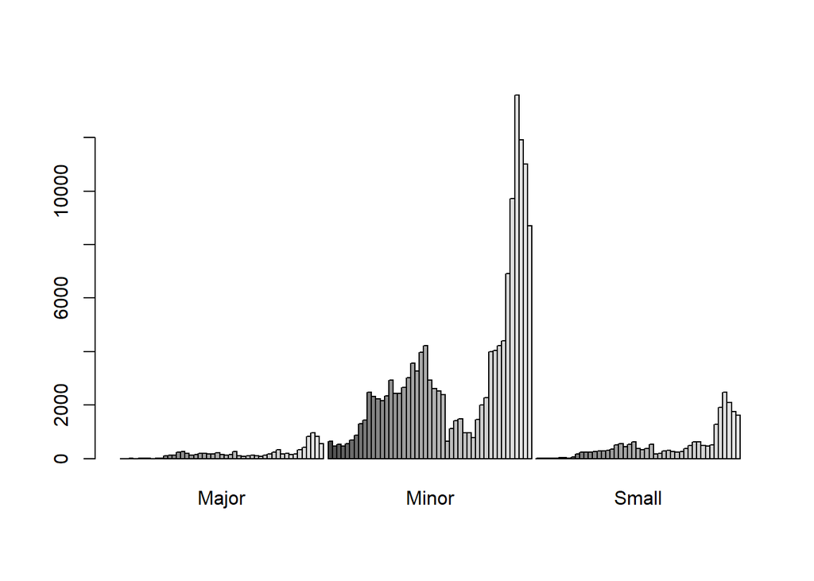

```r
terror_tb <- table(terror$year,terror$severity) #Pivot the data basis the year and severity
barplot(terror_tb,beside = T, legend.text = F)
```

We now have the yearly breakdown of the terrorist strikes basis the severity. The barplot provides us a bird’s eye view of the data and we see that there are a lot of **Minor** attacks which happen quite frequently. However, let’s do a deeper dive into the data.

```r
sum(is.na(terror_df$year)) #Ensure that the output is 0. It indicates there are no NA's or any other undesired values
```

```
## [1] 0
```

```r
sum(is.na(terror_df$nAttacks)) #Ensure that the output is 0.It indicates there are no NA's or any other undesired values
```

```
## [1] 0
```

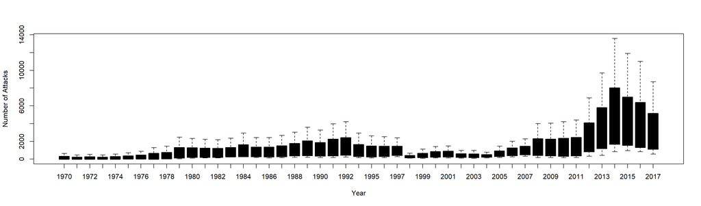

```r
plot(terror_df$year,terror_df$nAttacks,col=terror_df$severity,pch=20,xlab="Year",ylab="Number of Attacks") #Creates a boxplot
```

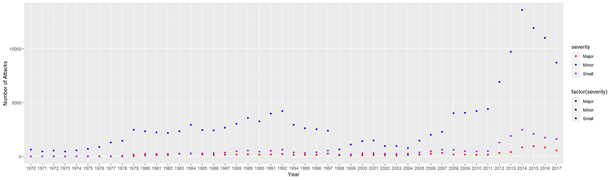

```r
ggplot(terror_df,aes(year,nAttacks,group=severity,fill=factor(severity))) + geom_point(aes(color=severity)) + scale_color_manual(values = c("red","blue","purple")) + xlab("Year") + ylab("Number of Attacks") #Scatter plot
```

Let’s do a simple regression analysis to analyse the relationship between number of attacks and year.

```r
set.seed(123) #For reproducability
terror_model <- lm(nAttacks~year,data = terror_df) #Regression model
summary(terror_model) #Check output
```

```
##
## Call:
## lm(formula = nAttacks ~ year, data = terror_df)
##
## Residuals:
##     Min      1Q  Median      3Q     Max
## -4797.3  -847.7  -333.3   647.0  7954.7
##
## Coefficients:
##             Estimate Std. Error t value Pr(>|t|)
## (Intercept)   217.00    1304.96   0.166  0.86829
## year1971      -60.00    1845.49  -0.033  0.97413
## year1972      -27.67    1845.49  -0.015  0.98807
## year1973      -59.33    1845.49  -0.032  0.97442
## year1974      -23.33    1845.49  -0.013  0.98994
## year1975       29.67    1845.49   0.016  0.98721
## year1976       90.67    1845.49   0.049  0.96092
## year1977      222.67    1845.49   0.121  0.90422
## year1978      291.67    1845.49   0.158  0.87476
## year1979      670.33    1845.49   0.363  0.71725
## year1980      670.33    1845.49   0.363  0.71725
## year1981      645.00    1845.49   0.350  0.72750
## year1982      631.00    1845.49   0.342  0.73318
## year1983      739.67    1845.49   0.401  0.68948
## year1984      948.00    1845.49   0.514  0.60868
## year1985      754.67    1845.49   0.409  0.68353
## year1986      736.33    1845.49   0.399  0.69081
## year1987      844.00    1845.49   0.457  0.64849
## year1988     1023.33    1845.49   0.555  0.58055
## year1989     1224.33    1845.49   0.663  0.50869
## year1990     1078.67    1845.49   0.584  0.56029
## year1991     1344.00    1845.49   0.728  0.46826
## year1992     1473.33    1845.49   0.798  0.42668
## year1994      935.00    1845.49   0.507  0.61359
## year1995      810.00    1845.49   0.439  0.66174
## year1996      802.33    1845.49   0.435  0.66474
## year1997      848.67    1845.49   0.460  0.64668
## year1998       94.33    1845.49   0.051  0.95934
## year1999      248.00    1845.49   0.134  0.89339
## year2000      387.67    1845.49   0.210  0.83407
```

[output cut: 8 more lines]

```
## year2009     1356.67    1845.49   0.735  0.46409
## year2010     1391.67    1845.49   0.754  0.45268
## year2011     1475.00    1845.49   0.799  0.42616
## year2012     2623.67    1845.49   1.422  0.15843
## year2013     3795.00    1845.49   2.056  0.04252 *
## year2014     5417.33    1845.49   2.935  0.00419 **
## year2015     4771.33    1845.49   2.585  0.01126 *
## year2016     4312.00    1845.49   2.337  0.02159 *
## year2017     3416.33    1845.49   1.851  0.06728 .
## ---
## Signif. codes:  0 '***' 0.001 '**' 0.01 '*' 0.05 '.' 0.1 ' ' 1
##
## Residual standard error: 2260 on 94 degrees of freedom
## Multiple R-squared:  0.3198, Adjusted R-squared:  -0.01312
## F-statistic: 0.9606 on 46 and 94 DF,  p-value: 0.5509
```

From the above model it becomes clear that there is no particular relationship between a calendar year and the frequency of terrorist attacks. This is **indicated particularly well by the respective p-values of the variable and the low R-squared value**. However, we do see that **2014 was particularly significant which is consistent with the peak of attack frequencies across the three varying severities**.

We’ll now superpose the regression lines over our earlier scatterplot.

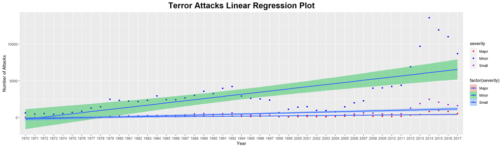

We see that the error margin for **Minor** terrorist attacks is very large. However, not so much for the **Major** and **Small** severities which is quite understandable as the trend for both of them are **fairly constant with low fluctuation**.  
**References:** 1.) https://dplyr.tidyverse.org/ 2.) http://courses.atlas.illinois.edu/spring2016/STAT/STAT200/RProgramming/RegressionFactors.html 3.) https://statisticsglobe.com/r-error-continuous-value-supplied-to-discrete-scale 4.) https://stackoverflow.com/questions/29587881/increase-plot-size-width-in-ggplot2